# Stochastic Integration

Bob Week

04-29-2020

## The Goal

- How do we make sense of $\left\{\begin{matrix} dX=b(X,t)dt+B(X,t)dW \\ X(0)=X_0 \end{matrix}\right.$ ?
- Rewrite as $X(t)=X_0+\int_0^tb(X,s)ds+\int_0^tB(X,s)dW(s)$.
- Can make sense of $\int_0^tb(X,s)ds$ for each fixed $\omega$.
  - That is, for each sample path.
- But what is $\int_0^tB(X,s)dW(s)$ ?
  - Todays topic!!

## A first definition

The Paley-Wiener-Zygmund (PWZ) stochastic integral

- Denote the set of continuously differentiable $g:[0,T]\to\mathbb{R}$ with $g(0)=g(T)=0$ by $C^1(0,T)$
- For $g\in C^1(0,T)$ define
- $$\int_0^Tg(t)dW(t):=-\int_0^Tg'(t)W(t)dt.$$
- If we pretend $W(t)$ is continuously differentiable, this coincides with integration by parts $\int_a^b udv=[uv]_a^b-\int_a^b vdu$.

## Properties of the PWZ integral

1. $\mathbb{E}\left(\int_0^TgdW\right)=0$
2. $\mathbb{E}\left[\left(\int_0^TgdW\right)^2\right]=\int_0^T g^2(t)dt$
- We assumed $g\in C^1(0,T)$. Since $[0,T]$ is a finite interval we have $g\in L^2(0,T)$ where …
- $L^2(0,T)$ is the space of functions $f$ on $[0,T]$ (not necessarily differentiable) such that $\int_0^Tf^2(t)dt<+\infty$.
- Hence, $C^1(0,T)\subset L^2(0,T).$

## The “standard machine”

A general method to extend operators

- Observe properties that characterize an operator defined on a set of “nice” functions.
- Try to define the operator on a larger set of functions while preserving the characteristic properties.
- The larger set of functions must contain the subset of “nice” functions in a special way.
  - We need the larger set of functions to be “complete” so that limits converge.
  - We need to approximate the general functions arbitrarily well with “nice” functions.

## A useful example

- For a set $U$ we define $L^2(U)$ as the space of square-integrable functions on $U$.
- That is, $f\in L^2(S)$ if $f:U\to\mathbb{R}$ and $\int_Uf^2(u)du<+\infty$.
- For $f,g\in L^2(U)$ we set $d(f,g)=\int_U(f(u)-g(u))^2du$
- We will see $L^2$ spaces often, so it is useful to note they are complete.
  - In particular, important limits converge in $L^2$ spaces.

## PWZ as an operator on $C^1(0,T)$

- Can think of PWZ integral as an operator mapping functions $g\in C^1(0,T)$ to random variables.
- Denote PWZ by $\mathcal{I}:C^1(0,T)\to L^2(\Omega)$
  - $L^2(\Omega)$ is the set of random variables with finite variance.
  - For $X,Y\in L^2(\Omega)$ we can measure their distance with
    $$\mathbb{E}\left[\left(X-Y\right)^2\right]=\int_\Omega\left(X(\omega)-Y(\omega)\right)^2\mathbb{P}(d\omega).$$
- To summarize, for any $g\in C^1(0,T)$:
  $$\mathbb{E}\left(\mathcal{I}(g)\right)=0$$
  $$\mathbb{V}\left(\mathcal{I}(g)\right)=\mathbb{E}\left[\left(\mathcal{I}(g)\right)^2\right]=\int_0^Tg^2(t)dt.$$

## $C^1(0,T)$ and $L^2(0,T)$

- For $f,g\in L^2(0,T)$ we measure the “distance” between them with
  $$d(f,g):=\int_0^T\big(f(t)-g(t)\big)^2dt.$$
- $C^1(0,T)$ is *dense* in $L^2(0,T)$.
- Thus, for any $f\in L^2(0,T)$, we can find $\{g_1,g_2,\dots\}\subset C^1(0,T)$ such that
  $$\lim_{n\to\infty}d(f,g_n)=0.$$

## An example

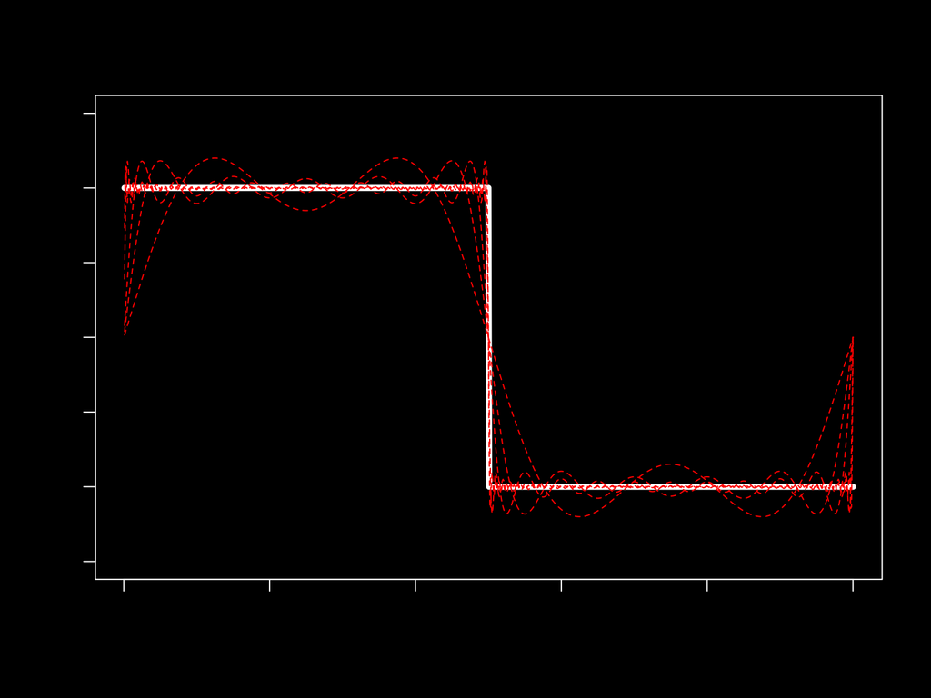

## Extending PWZ

- **Have:** $\mathcal{I}(g_n)\in L^2(\Omega)$ by definition.
- **Want:** $\lim_{n\to\infty}\mathcal{I}(g_n)\in L^2(\Omega)$.
- Property 2 of PWZ implies the isometry (same distance):
- $$\mathbb{E}\left[\left(\mathcal{I}(g_m)-\mathcal{I}(g_n)\right)^2\right]=d(g_m,g_n).$$
- Hence, the sequence $\{\mathcal{I}(g_n)\}_{n=1}^\infty$ converges in $L^2(\Omega)$.
- We can therefore define $\mathcal{I}(f):=\lim_{n\to\infty}\mathcal{I}(g_n)$.
- That is, $\int_0^Tf(t)dW(t):=\lim_{n\to\infty}\int_0^T g_n(t)dW(t)$.

## Before you break out the champagne

- PWZ only works for **deterministic** functions, not stochastic processes.
- How should we define $\int_0^T W(t)dW(t)$?
- Evans suggests we try a Riemann sum.

## Riemann sum approximation of

$\int_0^T W(t)dW(t)$

1. $P:=\{0=t_0<t_1<\cdots<t_m=T\}$ is a *partition* of $[0,T]$ with *mesh size* $|P|:=\max_k|t_{k+1}-t_k|$.
2. For $\lambda\in[0,1]$ set $\tau_k:=(1-\lambda)t_k+\lambda t_{k+1}$ so that $\tau_k\in[t_k,t_{k+1}]$.
3. The Riemann sum approximation is
   $$R(P,\lambda)=\sum_{k=0}^{m-1}W(\tau_k)\big(W(t_{k+1})-W(t_k)\big)$$

## What happens as $|P|\to0$ for fixed $\lambda$?

- Analogous to Riemann integrals, we might expect $\int_0^TW(t)dW(t)$
- But this is an integral with respect to a function instead of $dt$.
- Let’s try to make sense of as a Riemann-Stieltjes integral

## Riemann-Stieltjes integral

- A generalization of Riemann integration.
- Set $P_n:=\{a=t_0^n<\cdots<t_{m_n}^n=b\}$ such that $\lim_{n\to\infty}|P_n|=0$.
- Pick $\tau_i^n$ so that $t_i^n\leq\tau_i^n\leq t_{i+1}^n$.
- Define Riemann-Stieltjes integral of $g$ against $f$ as
- $$\int_0^Tg(t)df(t):=\lim_{n\to\infty}\sum_{i=0}^{m_n-1}g(\tau_i^n)(f(t_{i+1})-f(t_i))$$
- Requires $f$ to have finite *total variation*.

## Total variation

- Consider the set $\mathcal{P}$ of all partitions of $[0,T]$.
- Total variation for a function $f:[0,T]\to\mathbb{R}$ is
- $$V(f):=\sup_{P\in\mathcal{P}}\sum_{i=0}^{m_P-1}|f(t_{i+1})-f(t_i)|$$
  where $m_p$ is the number of intervals in $P$.
- Since $V(W)=+\infty$, we cannot define $\int_0^TW(t)dW(t)$ as a Riemann-Stieltjes integral.
- However, $R(P,\lambda)$ does converge as $|P|\to0$

## Quadratic variation (QV)

- Instead of considering total variation, we find the quadratic variation of Brownian Motion satisfies
- $$Q_n:=\sum_{k=1}^{m_n-1}\Big(W(t_{k+1}^n)-W(t_k^n)\Big)^2\to T$$
- More precisely, $\lim_{n\to\infty}\mathbb{E}\left[\big(Q_n-T\big)^2\right]=0$.

## Scaling relationship curiousity

- Evans states the result on QV partially explains $(dW)^2\approx dt$.
- To illustrate, recall the Riemann integral is given by
  $$\sum_{k=0}^{m_n-1}t^n_{k+1}-t^n_k\to\int_0^Tdt=T.$$
- Then the QV result suggests $\int_0^T(dW)^2=\int_0^Tdt$.

## Returning to the question:

What happens to $R(P,\lambda)$ when $|P|\to0$?

- We can use the QV result and properties of Brownian Motion to show
  $$\lim_{n\to\infty}R_n=\frac{W(T)^2}{2}+\left(\lambda-\frac{1}{2}\right)T$$
- Setting $\lambda=0$ coincides with the Itô integral
  $$\int_0^T WdW=\frac{1}{2}\Big(W(T)^2-T\Big).$$
- Setting $\lambda=\frac{1}{2}$ coincides with the Stratonovich integral
  $$\int_0^TW\circ dW=\frac{W(T)^2}{2}.$$

## Why is $\lambda=0$ a sensible choice?

- Consider the SDE
  $$dX=a(X,t)dt+B(X,t)dW$$
  and ODE
  $$\frac{dx}{dt}=a(x,t).$$
- Given solutions to both exist, we might expect $\mathbb{E}(X(t))=x(t)$.
- This only holds for $\lambda=0$ and requires processes to be *adapted* or *nonanticipating*

## Filtrations and adapted processes

- Fix the $\sigma$-algebra $\mathcal{U}$ and suppose
  - for each $t\geq0$ that $\mathscr{F}(t)$ is a sub-$\sigma$-algebra of $\mathcal{U}$
  - the collection $\{\mathscr{F}\}:=\{\mathscr{F}(t)\}_{t\geq0}$ satisfies $\mathscr{F}(s)\subset\mathscr{F}(t)$ when $s\leq t$.
- Then $\{\mathscr{F}\}$ is called a filtration of $\mathcal{U}$.
- Can think of $\mathscr{F}(t)$ as the set of all possible events up to time $t$.
  - Or, as the information available for a process up to time $t$.
- If all possible observations of $X(t)$ can be found in $\mathscr{F}(t)$ for each $t\geq0$ then $X(t)$ is *adapted* to $\{\mathscr{F}\}$.
- We’ll assume any process $X(t)$ is adapted to the filtration generated by $W(t)$.

## Progressively measurable processes

A note

- Since we take integrals over $\Omega$ and $[0,T]$ at the same time, we need more than adapted.
- Progressive measurability is a technical definition that takes care of these details.
- Turns out that adapted processes have progressively measurable versions.
- Hence, we can safely assume all the processes considered are progressively measurable

## Square-integrable processes

- If $G$ satisfies $\mathbb{E}\left(\int_0^TG^2(t)dt\right)<+\infty$, then we write
  $$G\in\mathbb{L}^2(0,T).$$
  - We’ll see Itô’s integral maps $\mathbb{L}^2(0,T)$ processes to random variables.

## Step processes

Approximations of $\mathbb{L}^2(0,T)$ processes

- Before we define Itô’s integral for $\mathbb{L}^2(0,T)$ processes, we look at simpler processes.
- If there is a partition ${\{t_k}\}_{k=1}^{m}$ of $[0,T]$ and a set of random variables $\{G_0,\dots,G_{m-1}\}$ such that
  - $G\in\mathbb{L}^2(0,T)$ satisfies
    $$G(t)=G_k, \ t\in[t_k,t_{k+1}), \ k=0,\dots,m-1,$$
  - then $G$ is called a *step process*.
- We can approximate $\mathbb{L}^2(0,T)$ processes arbitrarily close with step processes.

## Approximating $\mathbb{L}^2(0,T)$ processes

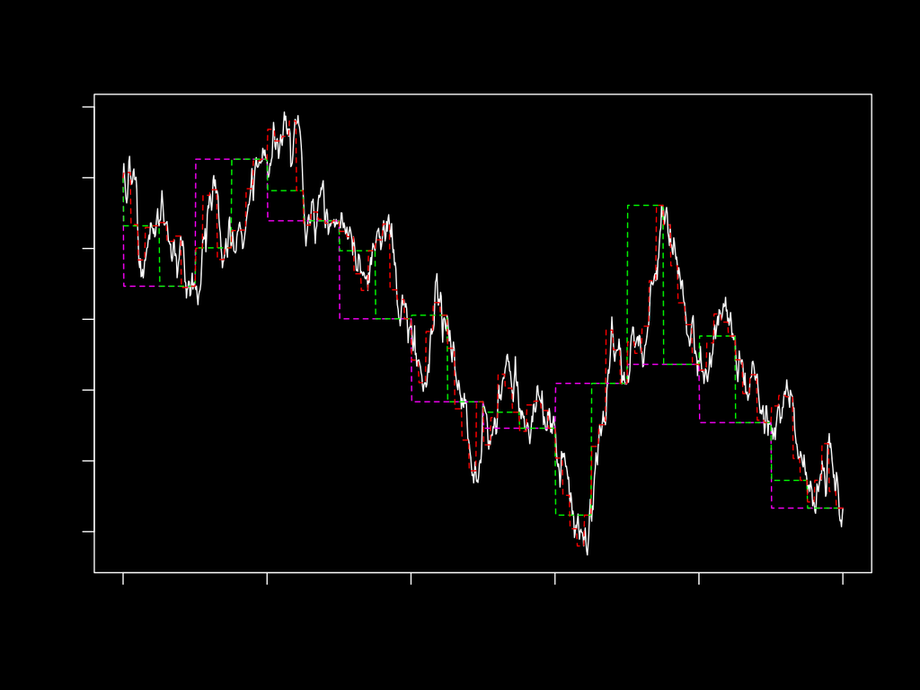

## Itô’s integral

For step processes

- For step processes $G$ we define the Itô integral by
  $$\mathscr{I}(G):=\int_0^TGdW:=\sum_{k=0}^{m-1}G_k\big(W(t_{k+1})-W(t_k)\big).$$

## Extending Itô’s integral

- **Have:** $\mathscr{I}(g_n)\in L^2(\Omega)$ by definition.
- **Want:** $\lim_{n\to\infty}\mathscr{I}(g_n)\in L^2(\Omega)$.

## Return of the standard machine

- Using properties of Lebesgue integration, we can show $\mathbb{L}^2(0,T)$ is complete.
- In particular, Cauchy sequences consisting of step processes converge in $\mathbb{L}^2(0,T)$.
- However, the standard machine requires us to show the space of step processes is dense in $\mathbb{L}^2(0,T)$.
- That is, we need for any $G\in\mathbb{L}^2(0,T)$ a sequence of step processes $G_n$ such that
  $$\mathbb{E}\left(\int_0^T(G-G_n)^2dt\right)\to0.$$

## Step processes from $\mathbb{L}^2(0,T)$ processes

- For $G\in\mathbb{L}^2(0,T)$, set
  $$G_m(t):=\int_0^tme^{m(s-t)}G(s)ds.$$
- Then $G_m$ is a continuous approximation of $G$ such that $d(G_m,G)\to0$ a.s. as $m\to\infty$.
- Set $G_{n,m}(t):=G_m(k/n)$ for $t\in[k/n,(k+1)/n)$ and $k=0,\dots,[nT]$.
- Then $G_{n,m}$ is a step function and $d(G_{n,m},G)\to0$ a.s. as $n,m\to\infty$.

## Itô’s integral

For $\mathbb{L}^2(0,T)$ processes

- For any $G$ in $\mathbb{L}^2(0,T)$ we can find a sequence $\{G_n\}$ of step processes that converges to $G$.
- The isometry property of Itô’s integral for step processes implies
- $$\mathbb{E}\left[\left(\int_0^TG_n-G_mdW\right)^2\right]=\mathbb{E}\left(\int_0^T(G_n-G_m)^2dt\right)\to0.$$
- Hence, we define Itô’s integral for $G$ as
- $$\mathscr{I}(G):=\lim_{n\to\infty}\int_0^TG_ndW$$

## Properties of Itô’s integral

- In analogy with step processes, we find for all $G,H\in\mathbb{L}^2(0,T)$
  1. $\mathscr{I}(aG+bH)=a\mathscr{I}(G)+b\mathscr{I}(H)$,
  2. $\mathbb{E}\left[\mathscr{I}(G)\right]=0$,
  3. $\mathbb{E}\left[\mathscr{I}(G)^2\right]=\mathbb{E}\left(\int_0^TG^2dt\right).$
- However, we now have the additional property
  4. $\mathbb{E}\left[\mathscr{I}(G)\mathscr{I}(H)\right]=\mathbb{E}\left(\int_0^TGHdt\right)\dots$ orthogonality.